# Understanding World Population Dynamics

Assignment 1 - PSYC593

Author

Ruiheng Sun

Published

October 2, 2024

Understanding population dynamics is important for many areas of social science. We will calculate some basic demographic quantities of births and deaths for the world’s population from two time periods: 1950 to 1955 and 2005 to 2010. We will analyze the following CSV data files - `Kenya.csv`, `Sweden.csv`, and `World.csv`. Each file contains population data for Kenya, Sweden, and the world, respectively. The table below presents the names and descriptions of the variables in each data set.

| Name | Description |
| --- | --- |
| `country` | Abbreviated country name |
| `period` | Period during which data are collected |
| `age` | Age group |
| `births` | Number of births in thousands (i.e., number of children born to women of the age group) |
| `deaths` | Number of deaths in thousands |
| `py.men` | Person-years for men in thousands |
| `py.women` | Person-years for women in thousands |

Source: United Nations, Department of Economic and Social Affairs, Population Division (2013). *World Population Prospects: The 2012 Revision, DVD Edition.*

Revision: delete some useless comments here.

Revision: revise the r chunk name to hide tidyverse package.

The data are collected for a period of 5 years where *person-year* is a measure of the time contribution of each person during the period. For example, a person that lives through the entire 5 year period contributes 5 person-years whereas someone who only lives through the first half of the period contributes 2.5 person-years. Before you begin this exercise, it would be a good idea to directly inspect each data set. In R, this can be done with the `View` function, which takes as its argument the name of a `data.frame` to be examined. Alternatively, in RStudio, double-clicking a `data.frame` in the `Environment` tab will enable you to view the data in a spreadsheet-like view.

## Question 1

We begin by computing *crude birth rate* (CBR) for a given period. The CBR is defined as:
$$\text{CBR}
= \frac{\text{number of births}}{\text{number of person-years lived}}$$

Compute the CBR for each period, separately for Kenya, Sweden, and the world. Start by computing the total person-years, recorded as a new variable within each existing `data.frame` via the `$` operator, by summing the person-years for men and women. Then, store the results as a vector of length 2 (CBRs for two periods) for each region with appropriate labels. You may wish to create your own function for the purpose of efficient programming. Briefly describe patterns you observe in the resulting CBRs.

### Answer 1

Revision: delete comments

```r
# Combine person-years for men and women into py for each dataset
# Revision: delete spaces
world_data$py <- world_data$py.men + world_data$py.women
kenya_data$py <- kenya_data$py.men + kenya_data$py.women
sweden_data$py <- sweden_data$py.men + sweden_data$py.women
```

```r
# Function to compute the Crude Birth Rate (CBR)
# Revision: change variable names
# Revision: generally revise into tidyverse style
compute_cbr <- function(pop_data) {
  pop_data %>%
    group_by(period) %>%
    summarise(cbr = sum(births) / sum(py)) %>%
    # Extract the 'cbr' values
    pull(cbr)
}
```

```r
# Compute the CBR for each data set
(world_cbr <- compute_cbr(world_data))
```

```
[1] 0.03732863 0.02021593
```

```r
(kenya_cbr <- compute_cbr(kenya_data))
```

```
[1] 0.05209490 0.03851507
```

```r
(sweden_cbr <- compute_cbr(sweden_data))
```

```
[1] 0.01539614 0.01192554
```

Revision: revise the somments

We could see The global crude birth rate has decreased during this period. Similarly, Sweden and Kenya show a downward trend, consistent with the global pattern, with Sweden maintaining a lower crude birth rate than Kenya throughout the entire period.

## Question 2

The CBR is easy to understand but contains both men and women of all ages in the denominator. We next calculate the *total fertility rate* (TFR). Unlike the CBR, the TFR adjusts for age compositions in the female population. To do this, we need to first calculate the *age specific fertility rate* (ASFR), which represents the fertility rate for women of the reproductive age range $[15, 50)$. The ASFR for age range $[x, x+\delta)$, where $x$ is the starting age and $\delta$ is the width of the age range (measured in years), is defined as:
$$\text{ASFR}_{[x,\ x+\delta)}
\ = \ \frac{\text{number of births to women of age $[x,\ x+\delta)$}}{\text{Number of person-years lived by women of age $[x,\ x+\delta)$}}$$
Note that square brackets, $[$ and $]$, include the limit whereas parentheses, $($ and $)$, exclude it. For example, $[20, 25)$ represents the age range that is greater than or equal to 20 years old and less than 25 years old. In typical demographic data, the age range $\delta$ is set to 5 years. Compute the ASFR for Sweden and Kenya as well as the entire world for each of the two periods. Store the resulting ASFRs separately for each region. What does the pattern of these ASFRs say about reproduction among women in Sweden and Kenya?

### Answer 2

Similarly, the study creates function for ASFR.

```r
# Function to compute Age specific fertility rate (ASFR)
compute_asfr <- function(pop_data) {
  pop_data %>%
    mutate(asfr = births / py.women)
}
```

Then, the study computes ASFR for each data set.

```r
world_data <- compute_asfr(world_data)
kenya_data <- compute_asfr(kenya_data)
sweden_data <- compute_asfr(sweden_data)
```

We combine Kenya and Sweden’s data on ASFR in the same diagram for comparison.

Revision: merge data and create a ggplot diagram.

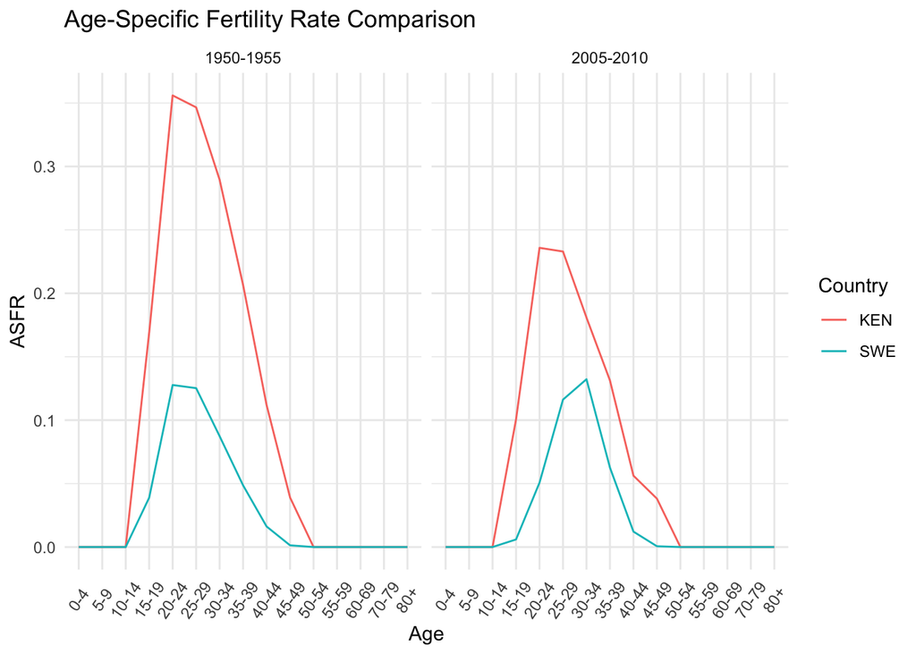

```r
# Now the two data sets are merged in one diagram based on the row
# Two data sets have the exact same row
kenya_sweden_compare <- rbind(kenya_data, sweden_data)

# Convert the 'age' column into a factor with specified levels for ordered
# categorical data
kenya_sweden_compare$age <- factor(kenya_sweden_compare$age,
  levels = c(
    "0-4", "5-9", "10-14", "15-19",
    "20-24", "25-29", "30-34", "35-39",
    "40-44", "45-49", "50-54", "55-59",
    "60-69", "70-79", "80+"
  )
)

# Create a line plot to compare ASFRs between Kenya and Sweden
kenya_sweden_ASFR <- kenya_sweden_compare %>%
  ggplot(aes(x = age, y = asfr, group = country, color = country)) +
  # Set aesthetics for Kenya and Sweden
  geom_line() + # Use geom_line() to create lines for each country
  labs(
    title = "Age-Specific Fertility Rate Comparison",
    x = "Age",
    y = "ASFR",
    color = "Country"
  ) +
  theme_minimal() +
  theme(axis.text.x = element_text(angle = 55, vjust = 0.5)) +
  facet_wrap(~period) # Create separate plots for each period to visualize
# differences over time

# Display the plot
kenya_sweden_ASFR
```

Revision: change the comment.

## Question 3

Using the ASFR, we can define the TFR as the average number of children women give birth to if they live through their entire reproductive age.
$$\text{TFR}
= \text{ASFR}_{[15,\ 20)} \times 5 + \text{ASFR}_{[20,\ 25)} \times 5
+ \dots + \text{ASFR}_{[45,\ 50)} \times 5$$

We multiply each age-specific fertility rate rate by 5 because the age range is 5 years. Compute the TFR for Sweden and Kenya as well as the entire world for each of the two periods. As in the previous question, continue to assume that women’s reproductive age range is $[15, 50)$. Store the resulting two TFRs for each country or the world as a vector of length two. In general, how has the number of women changed in the world from 1950 to 2000? What about the total number of births in the world?

### Answer 3

The study creates function to compute the total fertility rate (TFR) based on the provided population data.

```r
# Revision: generally revise into tidyverse style
# Function to compute the TRF
compute_tfr <- function(pop_data) {
  # Calculate TFR by period
  pop_data %>%
    group_by(period) %>%
    summarise(tfr = 5 * sum(asfr)) %>%
    pull(tfr)
}
```

Next, the study computes the TFR for three different datasets, and each dataset is passed to the `compute_tfr` function to obtain the respective TFR values.

```r
# Compute the TFR for each data set
(world_tfr <- compute_tfr(world_data))
```

```
[1] 5.007248 2.543623
```

```r
(kenya_tfr <- compute_tfr(kenya_data))
```

```
[1] 7.591410 4.879568
```

```r
(sweden_tfr <- compute_tfr(sweden_data))
```

```
[1] 2.226917 1.902764
```

```r
# Revision: generally revise into tidyverse style
# Compute totals of women and births in the world by period
(totals_world <- world_data %>%
  group_by(period) %>%
  summarise(
    total_women = sum(py.women),
    total_births = sum(births)
  )
)
```

```
# A tibble: 2 × 3
  period    total_women total_births
  <chr>           <dbl>        <dbl>
1 1950-1955    6555686.      488892.
2 2005-2010   16554781.      674581.
```

```r
# Compare how much these totals have changed
(changes_totals <- totals_world[2, -1] / totals_world[1, -1])
```

```
  total_women total_births
1    2.525256     1.379818
```

The results show that the total number of women during 2005-2010 is 2.525 times greater than that during 1950-1955, and total number of births during 2005-2010 is 1.380 times greater than that during 1950-1955.

## Question 4

Next, we will examine another important demographic process: death. Compute the *crude death rate* (CDR), which is a concept analogous to the CBR, for each period and separately for each region. Store the resulting CDRs for each country and the world as a vector of length two. The CDR is defined as:
$$\text{CDR}
= \frac{\text{number of deaths}}{\text{number of person-years lived}}$$
Briefly describe patterns you observe in the resulting CDRs.

```r
# Revision: generally revise into tidyverse style
# Function to compute the Crude death rate (CDR)
compute_cdr <- function(pop_data) {
  # Calculate CDR by period
  pop_data %>%
    group_by(period) %>%
    summarise(cdr = sum(deaths) / sum(py)) %>%
    pull(cdr)
}
```

```r
# Compute the CDR for each data set
(world_cdr <- compute_cdr(world_data))
```

```
[1] 0.019318929 0.008166083
```

```r
(kenya_cdr <- compute_cdr(kenya_data))
```

```
[1] 0.02396254 0.01038914
```

```r
(sweden_cdr <- compute_cdr(sweden_data))
```

```
[1] 0.009844842 0.009968455
```

## Question 5

One puzzling finding from the previous question is that the CDR for Kenya during the period of 2005-2010 is about the same level as that for Sweden. We would expect people in developed countries like Sweden to have a lower death rate than those in developing countries like Kenya. While it is simple and easy to understand, the CDR does not take into account the age composition of a population. We therefore compute the *age specific death rate* (ASDR). The ASDR for age range $[x, x+\delta)$ is defined as:
$$\text{ASDR}_{[x,\ x+\delta)}
\ = \ \frac{\text{number of deaths for people of age $[x,\ x+\delta)$}}
{\text{number of person-years of people of age $[x,\ x+\delta)$}}$$
Calculate the ASDR for each age group, separately for Kenya and Sweden, during the period of 2005-2010. Briefly describe the pattern you observe.

```r
# Revision: generally revise into tidyverse style
# Function to compute Age specific death rate (ASDR)
compute_asdr <- function(pop_data) {
  pop_data %>%
    # Compute ASDR as deaths per population
    mutate(asdr = deaths / py)
}
```

Next, the study uses the function `compute_asdr` to calculate ASDR.

```r
# Compute ASDR for each data set
world_data <- compute_asdr(world_data)
kenya_data <- compute_asdr(kenya_data)
sweden_data <- compute_asdr(sweden_data)
```

## Question 6

One way to understand the difference in the CDR between Kenya and Sweden is to compute the counterfactual CDR for Kenya using Sweden’s population distribution (or vice versa). This can be done by applying the following alternative formula for the CDR.
$$\text{CDR}
\ = \ \text{ASDR}_{[0, 5)} \times P_{[0,5)} + \text{ASDR}_{[5, 10)}
\times P_{[5, 10)} + \cdots$$
where $P_{[x, x+\delta)}$ is the proportion of the population in the age range $[x, x+\delta)$. We compute this as the ratio of person-years in that age range relative to the total person-years across all age ranges. To conduct this counterfactual analysis, we use $\text{ASDR}_{[x,x+\delta)}$ from Kenya and $P_{[x,x+\delta)}$ from Sweden during the period of 2005–2010. That is, first calculate the age-specific population proportions for Sweden and then use them to compute the counterfactual CDR for Kenya. How does this counterfactual CDR compare with the original CDR of Kenya? Briefly interpret the result.

```r
# Revision: generally revise into tidyverse style
# Function to compute population proportion by period
compute_pop_prop <- function(pop_data) {
  pop_data %>%
    group_by(period) %>%
    # Compute proportion of population
    mutate(pop_prop = py / sum(py)) %>%
    # Ungroup to avoid issues in further operations
    ungroup()
}
```

```r
# Compute population proportion for each data set
world_data <- compute_pop_prop(world_data)
kenya_data <- compute_pop_prop(kenya_data)
sweden_data <- compute_pop_prop(sweden_data)
```

Finally, the study calculates Kenya’s CDR using Sweden’s population distribution. This involves adjusting Kenya’s ASDR by the population proportions from Sweden and summarizing the results by period.

```r
# Revision: generally revise into tidyverse style
# Compute Kenya's CDR using Sweden's population distribution
kenya_cdr_sweden <- kenya_data %>%
  mutate(kenya_data,
    cfactual_cdr = asdr * sweden_data$pop_prop
  ) %>%
  group_by(period) %>%
  summarise(cdrresweden = sum(cfactual_cdr))
```